# DS7337_Class401_HW07_SGu

### SMU NLP Course (DS7337) -- Homework 07 submission (07-29-2019)

### Shanqing Gu (Class 401)

#### Q1. Clustering IDMB Movie Reviews

- Q1.1 - K-Means Clustering Models with k=4 and k=8
  - Q1.1.1 - Text Preprocessing and Feature Engineering
  - Q1.1.2 - K-Means Clustering model with k=4 (by main themes)
  - Q1.1.3 - K-Means Clustering model with k=4 (by pairwise document similarity)
  - Q1.1.4 - Plot K-Means Clustering results with k=4 (by pairwise document similarity)
  - Q1.1.5 - K-Means Clustering model with k=8 (by main themes)
  - Q1.1.6 - K-Means Clustering model with k=8 (by pairwise document similarity)
  - Q1.1.7 - Plot K-Means Clustering results with k=8 (by pairwise document similarity)
- Q1.2 - Hierarchical Clustering

#### Q2. What each cluster is generally centered on semantically?

- Q2.1 - The KMeans algorithm
- Q2.2 - The Hierarchical clustering algorithm

#### Q3. Compare clustering results with silhouette scores

- Q3.1 - Silhouette Coefficient from KMeans Models
- Q3.2 - Silhouette Coefficient from Hierarchical Clustering Models
- Q3.3 - Compare Silhouette Coefficient in Clustering Models

```python
## Import libraries needed for homework 07

import pandas as pd
import pickle
import re
import string

import matplotlib.pyplot as plt
%matplotlib inline

import nltk
from nltk import word_tokenize
from nltk.stem import WordNetLemmatizer

from collections import Counter
from html.parser import HTMLParser
from contractions import CONTRACTION_MAP

import seaborn as sns

from sklearn.feature_extraction.text import CountVectorizer
from sklearn.cluster import KMeans
from sklearn.metrics.pairwise import cosine_similarity
from sklearn.cluster import AgglomerativeClustering
from sklearn import metrics as mt
from sklearn.manifold import MDS

import scipy.cluster.hierarchy as sch
from scipy.cluster.hierarchy import ward, dendrogram, linkage

import warnings
import matplotlib.cbook
warnings.filterwarnings("ignore", category=DeprecationWarning)
warnings.filterwarnings("ignore",category=matplotlib.cbook.mplDeprecation)
```

#### Q1: Clustering Movie Reviews

In Python, select any one of the clustering methods covered in this course. Run it over the collection of reviews, and show at least two different ways of clustering the reviews, e.g., changing k in k-Means clustering or changing where you “cut” in Agnes or Diana.

Back to top

#### Q1.1: K-Means Clustering of Movie Reviews

In this Section, cluster the 956 movie reviews collected from homework 05 with the KMeans clustering algorithm.

This algorithm is a centroid-based clustering model to cluster data into groups or clusters of equal variances.

The number of clusters (k) should be specified in advance. Here, we compare the clustering results with k=4 and k=8.

Back to top

#### Q1.1.1 Text Preprocessing and Feature Engineering

Use the preprocessed movie reviews from homework 05.

Extract bag of words count based features for unigrams and bigrams (min_df =10 and max_df =0.8).

There are 956 movie reviews and 1561 features.

```python
## Movie review data was from HW-05
with open('Movies_reviews.p', 'rb') as f:
    MoviesReviews = pickle.load(f)
```

```python
## Check data movie review data with head()
MoviesReviews.head(3)
```

|  | Movie | rRating | rTitle | rReview | rAuthor | rDate | rLink | Scale | Chunks | Tokens |
| --- | --- | --- | --- | --- | --- | --- | --- | --- | --- | --- |
| 0 | A Quiet Place | 10/10 | For all the bashers of this movie | 1) The actress who is deaf in the movie is dea... | shaneandamy-196294 | August/2018 | http://www.imdb.com/review/rw4267600/?ref_=tt_... | 1 | [the actress, is, deaf, in, the movie, is, dea... | [actress, deaf, movie, deaf, real, life, alien... |
| 1 | A Quiet Place | 10/10 | Love it! | I am Deaf. I realllllly enjoy it!! So it good ... | zechpetersen7 | April/2018 | http://www.imdb.com/review/rw4119874/?ref_=tt_... | 1 | [i, am, deaf, i, realllllly enjoy, it, so, it,... | [deaf, realllllly, enjoy, good, people, know, ... |
| 2 | A Quiet Place | 8/10 | Nicely done horror + thriller, quite recommen... | "A Quiet Place" directed by John Krasinski is ... | NpMoviez17 | July/2018 | http://www.imdb.com/review/rw4242428/?ref_=tt_... | 1 | [a quiet place, directed, by, john krasinski, ... | [quiet, place, direct, john, krasinski, genuin... |

```python
## check data shape of movie reviews: 956
MoviesReviews.shape
```

```
(956, 10)
```

```python
## normalize_corpus function to normalize corpus
def normalize_corpus(corpus, lemmatize=True, only_text_chars=False, tokenize=False):

    normalized_corpus = []
    html_parser = HTMLParser()

    for text in corpus:
        text = html_parser.unescape(text)
        text = expand_contractions(text, CONTRACTION_MAP)

        if lemmatize:
            text = lemmatize_text(text)
        else:
            text = text.lower()
        text = remove_special_characters(text)
        text = remove_stopwords(text)

        if only_text_chars:
            text = keep_text_characters(text)

        if tokenize:
            text = tokenize_text(text)
            normalized_corpus.append(text)
        else:
            normalized_corpus.append(text)

    return normalized_corpus
```

```python
## expand_contractions function to expand contractions
def expand_contractions(text, contraction_mapping):
    contractions_pattern = re.compile('({})'.format('|'.join(contraction_mapping.keys())),
                                      flags=re.IGNORECASE|re.DOTALL)
    def expand_match(contraction):
        match = contraction.group(0)
        first_char = match[0]
        expanded_contraction = contraction_mapping.get(match)\
                               if contraction_mapping.get(match)\
                               else contraction_mapping.get(match.lower())
        expanded_contraction = first_char+expanded_contraction[1:]
        return expanded_contraction

    expanded_text = contractions_pattern.sub(expand_match, text)
    expanded_text = re.sub("'", "", expanded_text)
    return expanded_text
```

```python
## remove_special_characters function to remove special characters
def remove_special_characters(text):
    tokens = tokenize_text(text)
    pattern = re.compile('[{}]'.format(re.escape(string.punctuation)))
    filtered_tokens = filter(None, [pattern.sub(' ', token) for token in tokens])
    filtered_text = ' '.join(filtered_tokens)
    return filtered_text
```

```python
## tokenize_text function for tokenization
def tokenize_text(text):
    tokens = nltk.word_tokenize(text)
    tokens = [token.strip() for token in tokens]
    return tokens
```

```python
## remove_stopwords function to remove stop words
def remove_stopwords(text):
    tokens = tokenize_text(text)
    stopword_list = nltk.corpus.stopwords.words('english')
    filtered_tokens = [token for token in tokens if token not in stopword_list]
    filtered_text = ' '.join(filtered_tokens)
    return filtered_text
```

```python
## normalize the movie review corpus
Reviews_corpus = normalize_corpus(MoviesReviews.rReview, lemmatize=False )

## check one of the
Reviews_corpus[50]
```

```
'magnificent movie captivating performances bradley cooper lady gaga ultimate shock brilliant lady gaga knew could sing idea far acting talent stretches watching tell stretches far enough earn oscar gold movie outstanding music annoyingly perfect cast great everything shouts oscar worthy movie ten t…
```

```python
## Function for getting root words by lemmetization of the tokens
def lemming(tokens, pos = 'n'):

    lemma = WordNetLemmatizer()
    lemmad_list =[]

    for i in tokens:
        List =list(nltk.pos_tag([i])[0])[1]
        if(List in ['NNPS','NNS', 'NN']):
            pos = 'n' ## noun
        if(List in ['JJS','JJR']):
            pos ='a' ## adjective
        if(List in ['RB','RBS','RBR','MB', 'VBN', 'VBD', 'VBG']):
            pos ='v' ## verb and adverbs
        lemmad_list= lemmad_list+ [lemma.lemmatize(i, pos)]
    return lemmad_list
```

```python
## function for tokenizing the text and getting root words by lemmetization of the tokens
def Tokenize_text(text):
    RT = nltk.RegexpTokenizer(pattern=r'\s+',gaps =True)
    tokens = RT.tokenize(text)
    Tokens =lemming(tokens)
    return Tokens
```

```python
## Feature engineering
stop_words = nltk.corpus.stopwords.words('english')
stop_words = stop_words + ['one', 'two', 'get']

cv = CountVectorizer(ngram_range=(1,2), min_df=10, max_df=0.8, stop_words=stop_words, analyzer=Tokenize_text)
cv_matrix = cv.fit_transform(Reviews_corpus)
cv_matrix.shape
```

```
(956, 1561)
```

#### Q1.1.2: K-Means Clustering model with k=4 (by main themes)

```python
## use KMeans function to cluster the movie reviews
NUM_CLUSTERS_4 = 4
km4 = KMeans(n_clusters=NUM_CLUSTERS_4, max_iter=10000, n_init=50, random_state=42).fit(cv_matrix)

## view the distribution of movie reviews across the clusters
MoviesReviews['kmeans_cluster'] = km4.labels_
Counter(km4.labels_)
```

```
Counter({3: 713, 0: 70, 2: 149, 1: 24})
```

```python
## dataframe with kmeans_cluster labels
movie_clusters_4 = (MoviesReviews[['rTitle', 'rAuthor','rReview', 'kmeans_cluster', 'Scale']].sort_values(by=['kmeans_cluster', 'Scale'], ascending=False).groupby('kmeans_cluster').head(5))
movie_clusters_4.copy(deep=True)

feature_names_4 = cv.get_feature_names()
topn_features = 10 # only get the top 10 features
ordered_centroids_4 = km4.cluster_centers_.argsort()[:, ::-1]
```

```python
## get key features for each cluster and get reviews belonging to each other
for cluster_num_4 in range(NUM_CLUSTERS_4):
    key_features_4 = [feature_names_4[index] for index in ordered_centroids_4[cluster_num_4, :topn_features]]
    rAuthor_4 = movie_clusters_4[movie_clusters_4['kmeans_cluster'] == cluster_num_4]['rAuthor'].values.tolist()
    print('CLUSTER #' + str(cluster_num_4+1))
    print('Key Features:', key_features_4)
    print('Popular Review Authors:', rAuthor_4)
    print('-'*80)
```

```
CLUSTER #1
Key Features: ['movie', 'like', 'one', 'make', 'character', 'get', 'go', 'see', 'would', 'time']
Popular Review Authors: ['NpMoviez17', 'nancyldraper6', 'StaneSKT27', 'nothimme28', 'blparker-3173827']
--------------------------------------------------------------------------------
CLUSTER #2
Key Features: ['film', 'character', 'one', 'like', 'make', 'story', 'see', 'movie', 'would', 'time']
Popular Review Authors: ['michaeljohnson-2759722', 'themadmovieman3', 'shawneofthedead25', 'edgalarza21', 'ccamp899']
--------------------------------------------------------------------------------
CLUSTER #3
Key Features: ['film', 'movie', 'one', 'like', 'make', 'character', 'see', 'story', 'go', 'get']
Popular Review Authors: ['Blogger6621', 'ajwh-5359314', 'jimmyjohnjones6925', 'petra_ste20', 'Hellmant23']
--------------------------------------------------------------------------------
CLUSTER #4
Key Features: ['movie', 'film', 'like', 'one', 'see', 'story', 'character', 'make', 'watch', 'go']
Popular Review Authors: ['shaneandamy-196294', 'zechpetersen7', 'Platypuschow12', 'lynseylinzlu2', 'lwdiii7']
--------------------------------------------------------------------------------
```

#### Q1.1.3: K-Means Clustering model with k=4 (by pairwise document similarity)

```python
## group similar review by using pairwise document similarity
cosine_sim_features_4 = cosine_similarity(cv_matrix)
km4 = KMeans(n_clusters=NUM_CLUSTERS_4, max_iter=10000, n_init=50, random_state=42).fit(cosine_sim_features_4)
Counter(km4.labels_) ## count labels in each cluster
```

```
Counter({2: 287, 0: 265, 3: 220, 1: 184})
```

```python
## add new variable kmean_cluster to MovieReviews
MoviesReviews['kmeans_cluster'] = km4.labels_
movie_clusters_4 = (MoviesReviews[['rTitle', 'rAuthor','rReview', 'kmeans_cluster', 'Scale']].sort_values(by=['kmeans_cluster', 'Scale'], ascending=False).groupby('kmeans_cluster').head(5))
movie_clusters_4 = movie_clusters_4.copy(deep=True)
```

```python
## get movie reviews belonging to each cluster
for cluster_num_4 in range(NUM_CLUSTERS_4):
    rAuthor_4= movie_clusters_4[movie_clusters_4['kmeans_cluster'] == cluster_num_4]['rAuthor'].values.tolist()
    print('CLUSTER #' + str(cluster_num_4+1))
    print('Key Review Authors:', rAuthor_4)
    print('-'*80)
```

```
CLUSTER #1
Key Review Authors: ['NpMoviez17', 'Platypuschow12', 'lwdiii7', 'silvaback-135178', 'nancyldraper6']
--------------------------------------------------------------------------------
CLUSTER #2
Key Review Authors: ['popculturethoughts31', 'jwwalrath-227-8548717', 'Andreashairu18', 'thekingsdom16', 'chaouachiyoussef14']
--------------------------------------------------------------------------------
CLUSTER #3
Key Review Authors: ['shaneandamy-196294', 'zechpetersen7', 'saadgkhan15', 'tonyandaprilfrazier12', 'jeffreyhickman17']
--------------------------------------------------------------------------------
CLUSTER #4
Key Review Authors: ['lynseylinzlu2', 'Blogger6621', 'coolkevinsmith12', 'michaeljohnson-2759722', 'themadmovieman3']
--------------------------------------------------------------------------------
```

#### Q1.1.4: Plot K-Means Clustering results with k=4 (by pairwise document similarity)

```python
## precompute distance matrix with pairwise document similarity
dist_4 = 1 - cosine_similarity(cv_matrix)

MDS() # Multi-dimensional scaling

## convert two components for plotting points in a 2D plane
mds_4 = MDS(n_components=2, dissimilarity="precomputed", random_state=1) # 'random_state' for being reproducible

pos_4 = mds_4.fit_transform(dist_4)  # shape (n_components, n_samples)
xs4, ys4 = pos_4[:, 0], pos_4[:, 1]
```

```python
clusters_4 = km4.labels_.tolist()
scale_4 = MoviesReviews['Scale'].values.tolist()
```

```python
## set up colors per cluster using a dict
cluster_colors_4 = {0: '#1b9e77', 1: '#d95f02', 2: '#7570b3', 3: '#e7298a'}

## set up cluster names per cluster using a dict
cluster_names_4 = {0: 'Cluster #1', 1: 'Cluster #2', 2: 'Cluster #3', 3: 'Cluster #4'}
```

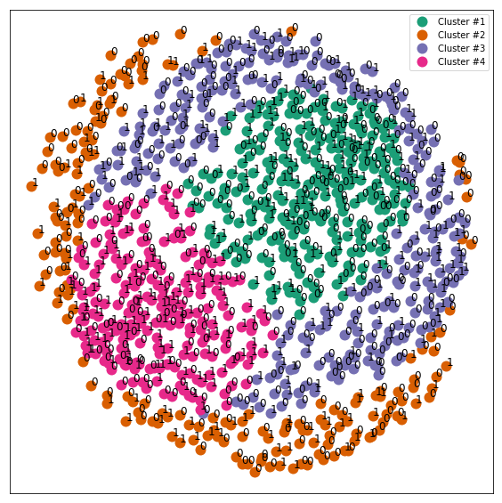

```python
## create data frame that has the result of the MDS plus the cluster numbers and titles
df_k4 = pd.DataFrame(dict(x=xs4, y=ys4, label=clusters_4, title=scale_4))

## group by cluster
groups = df_k4.groupby('label')

## set up plot
fig, ax = plt.subplots(figsize=(10, 10)) # set size
ax.margins(0.05) # Optional, just adds 5% padding to the autoscaling

## iterate through groups to layer the plot
## note that I use the cluster_name and cluster_color dicts with the 'name' lookup to return the appropriate color/label
for name, group in groups:
    ax.plot(group.x,
            group.y,
            marker='o', linestyle='',
            markersize=12,
            label=cluster_names_4[name],
            color=cluster_colors_4[name],
            mec='none')

    # ax.set_aspect('auto')
    ax.set_aspect('equal')
    ax.tick_params(\
        axis= 'x',          # changes apply to the x-axis
        which='both',      # both major and minor ticks are affected
        bottom='False',      # ticks along the bottom edge are off
        top='False',         # ticks along the top edge are off
        labelbottom='False')

    ax.tick_params(\
        axis= 'y',         # changes apply to the y-axis
        which='both',      # both major and minor ticks are affected
        left='False',      # ticks along the bottom edge are off
        top='False',         # ticks along the top edge are off
        labelleft='False')

ax.legend(numpoints=1)  #show legend with only 1 point

#add label in x,y position with the label as the film title
for i in range(len(df_k4)):
    ax.text(df_k4.ix[i]['x'], df_k4.ix[i]['y'], int(df_k4.ix[i]['title']), size=12)

## plt.show()

## save the plot
plt.savefig('km4_cluster.png', dpi=300)
```

#### Q1.1.5: K-Means Clustering model with k=8 (by main themes)

```python
## use KMeans function to cluster the movie reviews
NUM_CLUSTERS_8 = 8
km8 = KMeans(n_clusters=NUM_CLUSTERS_8, max_iter=1000, n_init=50, random_state=42).fit(cv_matrix)

## view the distribution of movie reviews across the clusters
MoviesReviews['kmeans_cluster'] = km8.labels_
Counter(km8.labels_)
```

```
Counter({0: 202, 4: 484, 5: 29, 2: 123, 3: 93, 1: 19, 6: 1, 7: 5})
```

```python
## dataframe with kmeans_cluster labels
movie_clusters_8 = (MoviesReviews[['rTitle', 'rAuthor','rReview', 'kmeans_cluster', 'Scale']].sort_values(by=['kmeans_cluster', 'Scale'], ascending=False).groupby('kmeans_cluster').head(4))
movie_clusters_8.copy(deep=True)

feature_names_8 = cv.get_feature_names()
topn_features = 10 # only get 10 features
ordered_centroids_8 = km8.cluster_centers_.argsort()[:, ::-1]
```

```python
## get key features for each cluster and get reviews belonging to each other
for cluster_num_8 in range(NUM_CLUSTERS_8):
    key_features_8 = [feature_names_8[index] for index in ordered_centroids_8[cluster_num_8, :topn_features]]
    rAuthor_8 = movie_clusters_8[movie_clusters_8['kmeans_cluster'] == cluster_num_8]['rAuthor'].values.tolist()
    print('CLUSTER #' + str(cluster_num_8+1))
    print('Key Features:', key_features_8)
    print('Popular Review Authors:', rAuthor_8)
    print('-'*80)
```

```
CLUSTER #1
Key Features: ['movie', 'like', 'see', 'one', 'watch', 'character', 'go', 'make', 'really', 'story']
Popular Review Authors: ['shaneandamy-196294', 'Platypuschow12', 'lwdiii7', 'silvaback-135178']
--------------------------------------------------------------------------------
CLUSTER #2
Key Features: ['film', 'character', 'like', 'make', 'one', 'movie', 'story', 'see', 'first', 'scene']
Popular Review Authors: ['michaeljohnson-2759722', 'themadmovieman3', 'shawneofthedead25', 'edgalarza21']
--------------------------------------------------------------------------------
CLUSTER #3
Key Features: ['film', 'one', 'like', 'make', 'character', 'see', 'movie', 'story', 'go', 'time']
Popular Review Authors: ['Blogger6621', 'ajwh-5359314', 'jimmyjohnjones6925', 'Hellmant23']
--------------------------------------------------------------------------------
CLUSTER #4
Key Features: ['movie', 'character', 'make', 'like', 'one', 'film', 'would', 'go', 'get', 'story']
Popular Review Authors: ['nancyldraper6', 'Platypuschow9', 'The_Man_XX726', 'jon.h.ochiai9']
--------------------------------------------------------------------------------
CLUSTER #5
Key Features: ['movie', 'film', 'story', 'one', 'see', 'like', 'make', 'time', 'good', 'get']
Popular Review Authors: ['zechpetersen7', 'lynseylinzlu2', 'popculturethoughts31', 'jwwalrath-227-8548717']
--------------------------------------------------------------------------------
CLUSTER #6
Key Features: ['movie', 'like', 'one', 'make', 'character', 'get', 'go', 'see', 'time', 'really']
Popular Review Authors: ['NpMoviez17', 'nothimme28', 'oliverdimitri26', 'CANpatbuck366411']
--------------------------------------------------------------------------------
CLUSTER #7
Key Features: ['battle', 'infinity', 'movie', 'thanos', 'character', 'war', 'action', 'get', 'go', 'really']
Popular Review Authors: ['milleniumlogan3']
--------------------------------------------------------------------------------
CLUSTER #8
Key Features: ['film', 'character', 'one', 'would', 'like', 'time', 'story', 'feel', 'even', 'work']
Popular Review Authors: ['littlemankazoo28', 'soulsk8ter22524', 'soulsk8ter22528', 'Bertaut20']
--------------------------------------------------------------------------------
```

#### Q1.1.6: K-Means Clustering model with k=8 (by pairwise document similarity)

```python
## group similar review by using pairwise document similarity
cosine_sim_features_8 = cosine_similarity(cv_matrix)
km8 = KMeans(n_clusters=NUM_CLUSTERS_8, max_iter=10000, n_init=50, random_state=42).fit(cosine_sim_features_8)
Counter(km8.labels_) ## count labels in each cluster
```

```
Counter({4: 160, 2: 138, 6: 102, 5: 141, 1: 86, 7: 92, 3: 126, 0: 111})
```

```python
## add new variable kmean_cluster to MovieReviews
MoviesReviews['kmeans_cluster'] = km8.labels_
movie_clusters_8 = (MoviesReviews[['rTitle', 'rAuthor','rReview', 'kmeans_cluster', 'Scale']].sort_values(by=['kmeans_cluster', 'Scale'], ascending=False).groupby('kmeans_cluster').head(4))
movie_clusters_8 = movie_clusters_8.copy(deep=True)
```

```python
## get movie reviews belonging to each cluster
for cluster_num in range(NUM_CLUSTERS_8):
    rAuthor_8= movie_clusters_8[movie_clusters_8['kmeans_cluster'] == cluster_num_8]['rAuthor'].values.tolist()
    print('CLUSTER #' + str(cluster_num_8+1))
    print('Key Review Authors:', rAuthor_8)
    print('-'*80)
```

```
CLUSTER #8
Key Review Authors: ['michaeljohnson-2759722', 'ajwh-5359314', 'jimmyjohnjones6925', 'clark-ingleton17']
--------------------------------------------------------------------------------
CLUSTER #8
Key Review Authors: ['michaeljohnson-2759722', 'ajwh-5359314', 'jimmyjohnjones6925', 'clark-ingleton17']
--------------------------------------------------------------------------------
CLUSTER #8
Key Review Authors: ['michaeljohnson-2759722', 'ajwh-5359314', 'jimmyjohnjones6925', 'clark-ingleton17']
--------------------------------------------------------------------------------
CLUSTER #8
Key Review Authors: ['michaeljohnson-2759722', 'ajwh-5359314', 'jimmyjohnjones6925', 'clark-ingleton17']
--------------------------------------------------------------------------------
CLUSTER #8
Key Review Authors: ['michaeljohnson-2759722', 'ajwh-5359314', 'jimmyjohnjones6925', 'clark-ingleton17']
--------------------------------------------------------------------------------
CLUSTER #8
Key Review Authors: ['michaeljohnson-2759722', 'ajwh-5359314', 'jimmyjohnjones6925', 'clark-ingleton17']
--------------------------------------------------------------------------------
CLUSTER #8
Key Review Authors: ['michaeljohnson-2759722', 'ajwh-5359314', 'jimmyjohnjones6925', 'clark-ingleton17']
--------------------------------------------------------------------------------
CLUSTER #8
Key Review Authors: ['michaeljohnson-2759722', 'ajwh-5359314', 'jimmyjohnjones6925', 'clark-ingleton17']
--------------------------------------------------------------------------------
```

#### Q1.1.7: Plot K-Means Clustering results with k=8 (by pairwise document similarity)

```python
## precompute distance matrix with pairwise document similarity
dist_8 = 1 - cosine_similarity(cv_matrix)

MDS()

## convert two components for plotting points in a 2D plane
mds_8 = MDS(n_components=2, dissimilarity="precomputed", random_state=1) # 'random_state' for being reproducible

pos_8 = mds_8.fit_transform(dist_8)  # shape (n_components, n_samples)
xs8, ys8 = pos_8[:, 0], pos_8[:, 1]
```

```python
clusters_8 = km8.labels_.tolist()
scale_8 = MoviesReviews['Scale'].values.tolist()
```

```python
## set up colors per cluster using a dict
cluster_colors_8 = {0: '#1b9e77', 1: '#d95f02', 2: '#7570b3', 3: '#e7298a',
                  4: '#66a61e', 5:'#FF6347', 6:'#00ffff', 7:'#c0c0c0'}

## set up cluster names per cluster using a dict
cluster_names_8 = {0: 'Cluster #1', 1: 'Cluster #2', 2: 'Cluster #3', 3: 'Cluster #4',
                 4: 'Cluster #5', 5: 'Cluster #6', 6: 'Cluster #7', 7: 'Cluster #8'}
```

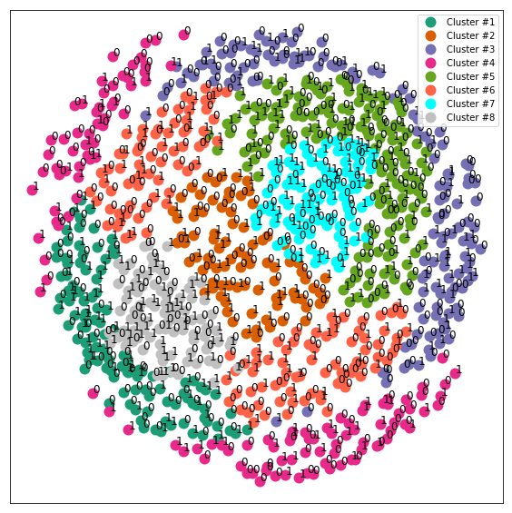

```python
## create data frame that has the result of the MDS plus the cluster numbers and titles
df_k8 = pd.DataFrame(dict(x=xs8, y=ys8, label=clusters_8, title=scale_8))

## group by cluster
groups = df_k8.groupby('label')

## set up plot
fig, ax = plt.subplots(figsize=(10, 10)) # set size
ax.margins(0.05) # Optional, just adds 5% padding to the autoscaling

## iterate through groups to layer the plot
## note that I use the cluster_name and cluster_color dicts with the 'name' lookup to return the appropriate color/label
for name, group in groups:
    ax.plot(group.x,
            group.y,
            marker='o', linestyle='',
            markersize=12,
            label=cluster_names_8[name],
            color=cluster_colors_8[name],
            mec='none')

    # ax.set_aspect('auto')
    ax.set_aspect('equal')
    ax.tick_params(\
        axis= 'x',          # changes apply to the x-axis
        which='both',      # both major and minor ticks are affected
        bottom='False',      # ticks along the bottom edge are off
        top='False',         # ticks along the top edge are off
        labelbottom='False')

    ax.tick_params(\
        axis= 'y',         # changes apply to the y-axis
        which='both',      # both major and minor ticks are affected
        left='False',      # ticks along the bottom edge are off
        top='False',         # ticks along the top edge are off
        labelleft='False')

ax.legend(numpoints=1)  #show legend with only 1 point

#add label in x,y position with the label as the film title
for i in range(len(df_k8)):
    ax.text(df_k8.ix[i]['x'], df_k8.ix[i]['y'], int(df_k8.ix[i]['title']), size=12)

## plt.show()

## save the plot
plt.savefig('km8_cluster.png', dpi=300)
```

#### Q1.2: Hierarchical Clustering of Movie Reviews

In Python, select any one of the clustering methods covered in this course. Run it over the collection of reviews, and show at least two different ways of clustering the reviews, e.g., changing k in k-Means clustering or changing where you “cut” in Agnes or Diana.

Back to top

Hierarchical clustering, as depicted by a tree or dendrogram, can be divided into agglomerative ("from the bottom up") and divisive clustering ("from the top down").

```python
## function for Ward's agglomerative hierarchical clustering
def ward_hierarchical_clustering(cv_matrix):
    cosine_distance = 1 - cosine_similarity(cv_matrix)
    linkage_matrix = ward(cosine_distance)
    return linkage_matrix
```

```python
## function for plotting hierarchical clusters
def plot_hierarchical_clusters(linkage_matrix, MoviesReviews, p=100, figure_size=(8,12)):

    fig, ax = plt.subplots(figsize=figure_size)
    movie_titles = MoviesReviews['rAuthor'].values.tolist()

    R = dendrogram(linkage_matrix, orientation="left", labels=movie_titles, truncate_mode='lastp', p=p, no_plot=True)
    temp = {R["leaves"][ii]:MoviesReviews.rTitle[ii] for ii in range(len(R["leaves"]))}

    def llf(xx):
        return "{}".format(temp[xx])

    ax = dendrogram(linkage_matrix,
                    orientation="left",
                    labels=movie_titles,
                    truncate_mode='lastp',
                    p=p,
                    leaf_label_func = llf,
                    leaf_font_size=10)

    plt.tick_params(axis= 'x',
                    which='both',
                    bottom='False',
                    top='False',
                    labelbottom='False')

    plt.tight_layout()
    plt.savefig('hc_clusters.png', dpi=300)
```

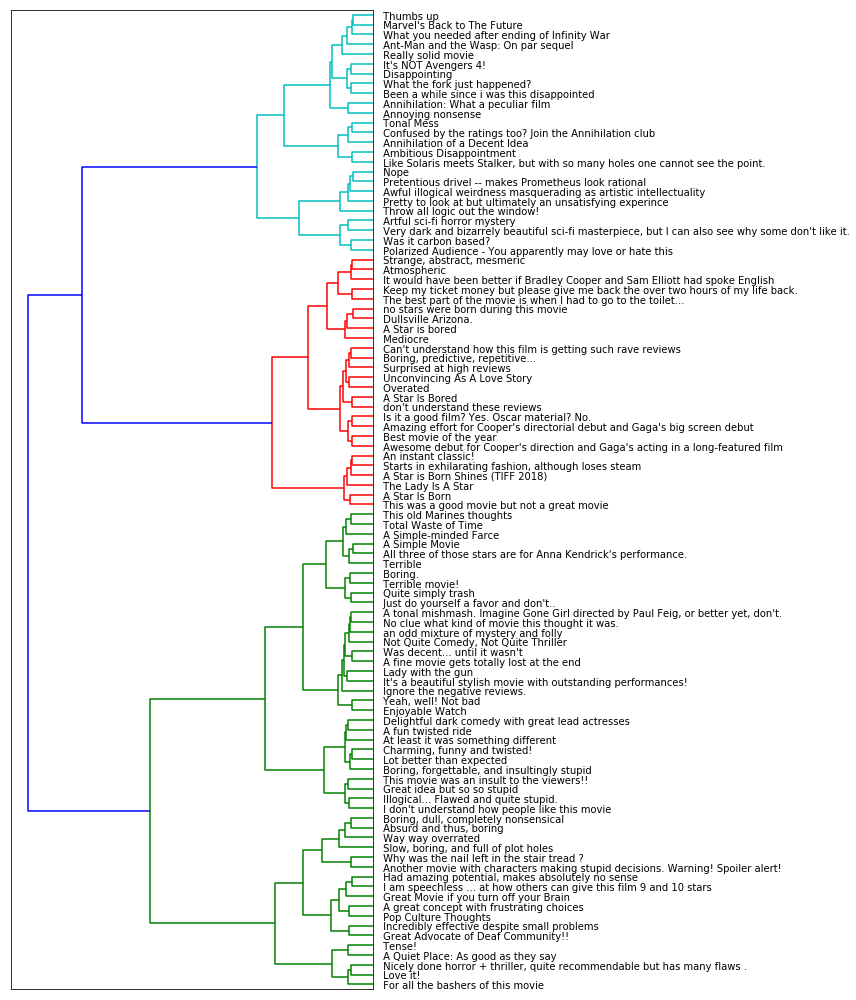

```python
## build ward's linkage matrix
linkage_matrix = ward_hierarchical_clustering(cv_matrix)

## plot the dendrogram
plot_hierarchical_clusters(linkage_matrix=linkage_matrix,
                           p=100,
                           MoviesReviews=MoviesReviews,
                           figure_size=(12,14))
```

#### Q2: What each cluster is generally centered on semantically

Try to write a short phrase to characterize (give a natural interpretation of) what each cluster is generally centered on semantically. Is this hard to do in some cases? If so, make note of that fact.

Back to top

#### Q2.1 The KMeans algorithm

The KMeans algorithm clusters data by trying to separate samples in n groups of equal variances, minimizing a criterion known as the inertia (within-cluster sum-of-squares) which can be recognized as a measure of how internally coherent clusters are. This algorithm requires the number of clusters to be specified.

'inertia' is the sum of squared distances of samples to their closest cluster center.

The Silhouette coefficient is calculated using the mean intra-cluster distance (a) and the mean nearest-cluster distance (b) for each sample. The Silhouette Coefficient for a sample is (b - a) / max(a, b). The best value is 1 and the worst value is -1. Values near 0 indicate overlapping clusters. Negative values generally indicate that a sample has been assigned to the wrong cluster, as a different cluster is more similar.

In this homework, the inertia and silhouette Coefficient are used to compare the models with n_clusters 4 and 8. The results indicate the KMeans clustering algorithm performs better when n_clusters (k) = 4 (silhouette coefficient = 0.19).

```python
kmeans_inertia_4 = km4.inertia_
print ("inertia = ", kmeans_inertia_4)
```

```
inertia =  3505.4554341360413
```

```python
kmeans_silhouette_4 = mt.silhouette_score(dist_4, clusters_4 , metric = 'euclidean', sample_size = 10000)
print ("silhouette = ", kmeans_silhouette_4)
```

```
silhouette =  0.1943340486167054
```

```python
kmeans_inertia_8 = km8.inertia_
print ("inertia = ", kmeans_inertia_8)
```

```
inertia =  2889.647035054938
```

```python
kmeans_silhouette_8 = mt.silhouette_score(dist_8, clusters_8 , metric = 'euclidean', sample_size = 10000)
print ("silhouette = ", kmeans_silhouette_8)
```

```
silhouette =  0.12543755840237442
```

#### Q2.2 The Hierarchical clustering algorithm

Hierarchical clustering, as depicted by a tree or dendrogram, can be divided into agglomerative ("from the bottom up") and divisive clustering ("from the top down").

There are four linkages (complete, average, ward and single) linkage for hierarchical agglomerative clustering with the basic idea to repeatedly merge two most similar groups as measured by the linkage. Complete linkage measures the farthest pair of points, average linkage measures the average dissimilarity over all pairs, ward linkage measures how much the sum of squares will increase when we merge two clusters, and single linkage measures the closest pair of points.

In this homework, the hierarchical clustering algorithm (linkage 'ward', and n_clusters = 4) performs better (silhouette coefficient = 0.45).

```python
hc_ward_4 = AgglomerativeClustering(4, affinity = 'euclidean', linkage = 'ward')
hc_ward_4.fit(linkage_matrix)

hc_labels_ward_4 = hc_ward_4.labels_

hc_silhouette_4 = mt.silhouette_score(linkage_matrix, hc_labels_ward_4, metric = 'euclidean', sample_size = 1000)
print ("silhouette = ", hc_silhouette_4)
```

```
silhouette =  0.45066423775692366
```

```python
hc_ward_8 = AgglomerativeClustering(8, affinity = 'euclidean', linkage = 'ward')
hc_ward_8.fit(linkage_matrix)

hc_labels_ward_8 = hc_ward_8.labels_

hc_silhouette_8 = mt.silhouette_score(linkage_matrix, hc_labels_ward_8, metric = 'euclidean', sample_size = 1000)
print ("silhouette = ", hc_silhouette_8)
```

```
silhouette =  0.36783988124777534
```

#### Q3 : Compare clustering results with silhouette coefficient

Explain which of the two clustering results from question 1 is preferable (if one of them is), and why.

Back to top

```python
## create table for comparison of models
HC_table = pd.DataFrame(columns = ['Model', 'n_clusters', 'Silhouette Coefficient'])

i_index = []
i_index = 0

## each classifier is appended once model is fit
models = []
```

#### Q3.1 Silhouette Coefficient from KMeans Models¶

```python
kmeans_silhouette_4 = mt.silhouette_score(dist_4, clusters_4 , metric = 'euclidean', sample_size = 1000)
print ("Silhouette Coefficient = ", kmeans_silhouette_4)

raw_data = {'Model': 'Kmeans_k4', 'n_clusters': 4, 'Silhouette Coefficient': kmeans_silhouette_4}
df_tbl = pd.DataFrame(raw_data, columns = ['Model', 'n_clusters', 'Silhouette Coefficient'], index = [i_index + 1])
HC_table = HC_table.append(df_tbl, sort=False)
```

```
Silhouette Coefficient =  0.1943340486167054
```

```python
kmeans_silhouette_8 = mt.silhouette_score(dist_8, clusters_8, metric = 'euclidean', sample_size = 1000)
print ("Silhouette Coefficient = ", kmeans_silhouette_8)

raw_data = {'Model': 'Kmeans_k8', 'n_clusters': 8, 'Silhouette Coefficient': kmeans_silhouette_8}
df_tbl = pd.DataFrame(raw_data, columns = ['Model', 'n_clusters', 'Silhouette Coefficient'], index = [i_index + 1])
HC_table = HC_table.append(df_tbl, sort=False)
```

```
Silhouette Coefficient =  0.1254375584023744
```

#### Q3.2 Silhouette Coefficient from Hierarchical Clustering Models

```python
hc_ward_4 = AgglomerativeClustering(4, affinity = 'euclidean', linkage = 'ward')
hc_ward_4.fit(linkage_matrix)

hc_labels_ward_4 = hc_ward_4.labels_

hc_silhouette_4 = mt.silhouette_score(linkage_matrix, hc_labels_ward_4, metric = 'euclidean', sample_size = 1000)
print ("Silhouette Coefficient = ", hc_silhouette_4)

raw_data = {'Model': 'Hierarchical_4', 'n_clusters': 4, 'Silhouette Coefficient': hc_silhouette_4}
df_tbl = pd.DataFrame(raw_data, columns = ['Model', 'n_clusters', 'Silhouette Coefficient'], index = [i_index + 1])
HC_table = HC_table.append(df_tbl, sort=False)
```

```
Silhouette Coefficient =  0.45066423775692366
```

```python
hc_ward_8 = AgglomerativeClustering(8, affinity = 'euclidean', linkage = 'ward')
hc_ward_8.fit(linkage_matrix)

hc_labels_ward_8 = hc_ward_8.labels_

hc_silhouette_8 = mt.silhouette_score(linkage_matrix, hc_labels_ward_8, metric = 'euclidean', sample_size = 1000)
print ("silhouette Coefficient= ", hc_silhouette_8)

raw_data = {'Model': 'Hierarchical_8', 'n_clusters': 8, 'Silhouette Coefficient': hc_silhouette_8}
df_tbl = pd.DataFrame(raw_data, columns = ['Model', 'n_clusters', 'Silhouette Coefficient'], index = [i_index + 1])
HC_table = HC_table.append(df_tbl, sort=False)
```

```
silhouette Coefficient=  0.36783988124777534
```

#### Q3.3 - Compare Silhouette Coefficient in Clustering Models

The silhouette coefficient is a measure of how similar an object is to its own cluster compared to other clusters. The silhouette ranges from −1 to +1, where a high value indicates that the object is well matched to its own cluster and poorly matched to neighboring clusters. The silhouette coefficients can be calculated with any distance metric

From the silhouette coefficient results in 4 clustering models, the hierarchical clustering algorithm (linkage 'ward', and n_clusters = 4) performs best (silhouette coefficient = 0.45).

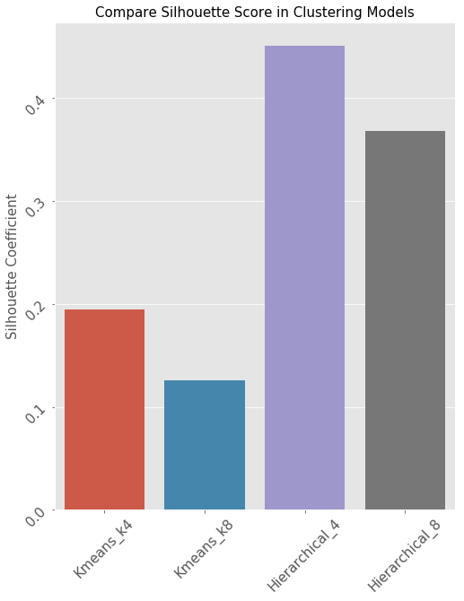

```python
sns.set_palette("husl")
plt.style.use('ggplot')

plt.figure(figsize=(8,10))
b = sns.barplot(x = "Model", y = "Silhouette Coefficient", data = HC_table)

b.axes.set_title("Compare Silhouette Score in Clustering Models",fontsize=15)
b.set_xlabel("", fontsize=15)
b.set_ylabel("Silhouette Coefficient",fontsize=15)
b.tick_params(labelsize=15, rotation = 45)

plt.savefig('compare_models.png', dpi=300)
```

#### References

1. Sarkar D. Text analytics with Python, 2nd edition
2. Document Clustering with Python (http://brandonrose.org/clustering)

#### Implementation environments¶

```python
import platform; print(platform.platform())
import sys; print("Python", sys.version)
import pandas;  print("Pandas", pandas.__version__)
import numpy; print("NumPy", numpy.__version__)
import requests; print("Requests", requests.__version__)
import pickle; print("Pickle", pickle.format_version)
import re; print("Re", re.__version__)
import nltk; print("nltk", nltk.__version__)
import matplotlib; print("Matplotlib", matplotlib.__version__)
import sklearn; print("Sklearn", sklearn.__version__)
import scipy; print("Scipy", scipy.__version__)
```

```
Darwin-18.6.0-x86_64-i386-64bit
Python 3.6.8 |Anaconda, Inc.| (default, Dec 29 2018, 19:04:46)
[GCC 4.2.1 Compatible Clang 4.0.1 (tags/RELEASE_401/final)]
Pandas 0.24.2
NumPy 1.16.4
Requests 2.22.0
Pickle 4.0
Re 2.2.1
nltk 3.4
Matplotlib 3.0.2
Sklearn 0.21.2
Scipy 1.2.1
```

-- The End of Homework 07 --